# Spatial Data Analysis (450:320)

Class 11

## We have learned

- All necessary data manipulation!
- Of course you could learn more by yourself

## Today

- Figures
- Tables

**Note**: create an R markdown for today’s class.

## Tables

Package [`kableExtra`](https://cran.r-project.org/web/packages/kableExtra/vignettes/awesome_table_in_html.html)

Basic syntax is:

```r
library(kableExtra)
crops <- read.csv(here('docs/Crop_recommendation.csv')) %>% slice(1:5)

crops %>%
    kbl(digits = 1, caption = 'First 5 observations') %>%
    kable_paper(lightable_options = 'basic', # could be basic, striped, or hover
                html_font = 'helvetica', # could be any font installed on your machine.
                font_size = 12, # font size
                full_width = FALSE, # full width or not
                position = "left", # center, left, right, or float-left and float-right
                fixed_thead = T) %>% # for a very long cross-pages table.
    column_spec(1, bold = T, background = 'pink') %>% # customize a column
    row_spec(1:5, color = 'white') %>%
    row_spec(which(crops$temperature == max(crops$temperature)),
             italic = TRUE, color = 'red') # customize a row
```

First 5 observations

| N | P | K | temperature | humidity | ph | rainfall | label |
| --- | --- | --- | --- | --- | --- | --- | --- |
| 90 | 42 | 43 | 20.9 | 82.0 | 6.5 | 202.9 | rice |
| 85 | 58 | 41 | 21.8 | 80.3 | 7.0 | 226.7 | rice |
| 60 | 55 | 44 | 23.0 | 82.3 | 7.8 | 264.0 | rice |
| 74 | 35 | 40 | 26.5 | 80.2 | 7.0 | 242.9 | rice |
| 78 | 42 | 42 | 20.1 | 81.6 | 7.6 | 262.7 | rice |

## Base scatterplot

```r
crops <- read.csv(here('docs/Crop_recommendation.csv'))
# set the margin, c(bottom, left, top, right)
par(mar = c(3, 4, 3, 4))
# Make the main plot
plot(x = crops$ph, y = crops$rainfall, # set x and y
     pch = 20, col = 'blue', # set points style
     main = 'Relationship between ph and rainfall', # add main
     col.main = 'brown', # set main color
     xlab = 'ph', ylab = 'Rainfall') # set x and y axis

# Add a fit line
abline(lm(crops$rainfall ~ crops$ph),
       lty = 3, lwd = 3, col = 'black')

# Add legend
legend("topright", pch = c(20, 18),
       col = "blue",
       legend = "Rainfall")
```

## Base scatterplot

[figure not shown]

## Your turn

- Copy the code and revise the arguments (variables, colors, etc) to your own choices.
- Share your figure in Google chat.

More choices on style of points or lines:

- `pch`: http://www.sthda.com/english/wiki/r-plot-pch-symbols-the-different-point-shapes-available-in-r
- `lty`: http://www.sthda.com/english/wiki/line-types-in-r-lty

## Double y axises

```r
# set the margin, c(bottom, left, top, right)
par(mar = c(3, 4, 3, 4))
# Make the main plot
plot(crops$ph, crops$rainfall, # set x and y
     pch = 20, col = 'blue', # set points style
     main = 'Relationship between ph, rainfall and humidity', # add main
     col.main = 'brown', # set main color
     xlab = 'ph', ylab = 'Rainfall') # set x and y axis

# Add a fit line
abline(lm(crops$rainfall ~ crops$ph),
       lty = 3, lwd = 3, col = 'blue')

# THE TRICK: Add another scatterplot using points
## Reset plot window
plot.window(xlim = range(crops$ph),
            ylim = range(crops$humidity))

## Another syntax to use plot: with(dataset, plot(x, y))
with(crops, points(ph, humidity,
                   pch = 18, col = 'orange'))
# Add fit line
with(crops, abline(lm(humidity ~ ph),
                   lty = 4, lwd = 2,
                   col = 'orange'))

# Add another axis
axis(4, col.axis = "orange")
## Add lab for this axis
mtext(side = 4, line = 2, "Humidity", col = 'orange')

# Add legend
legend("topright", pch = c(20, 18),
       col = c("blue", "orange"),
       legend = c("Rainfall", "Humidity"))
```

## Double y axises

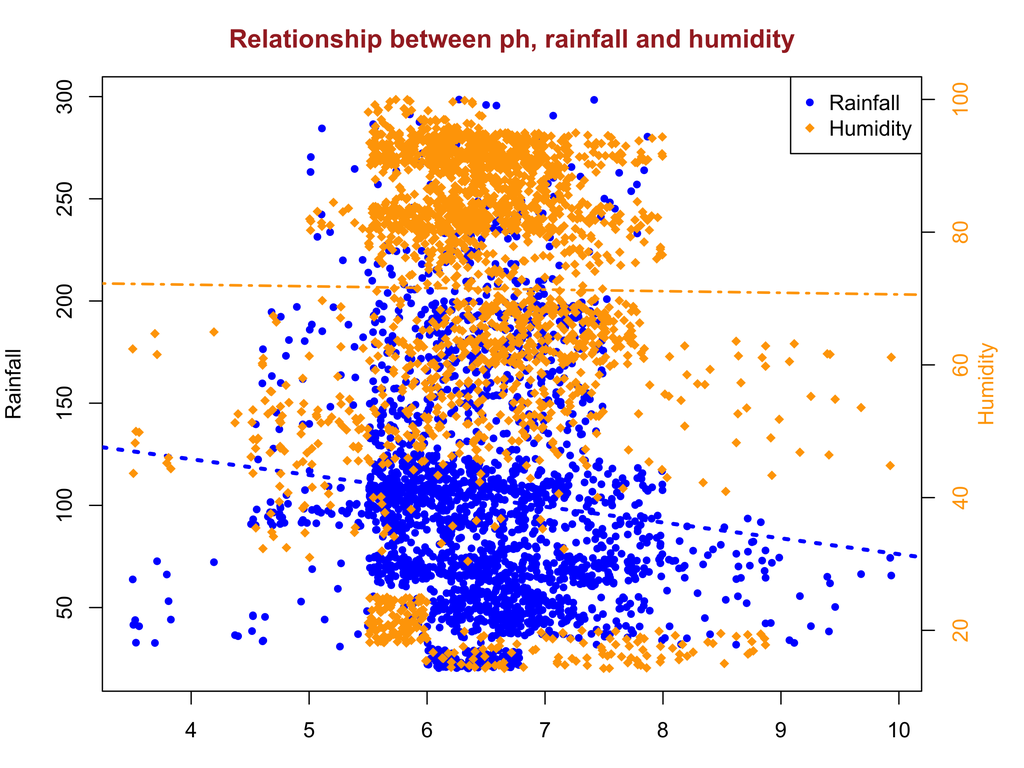

## Your turn

The same:

- Copy the code and revise the arguments (variables, colors, etc) to your own choices.
- Share your figure in Google chat.

## Others

- `hist` (histogram)
- `boxplot`
- `par(mfrow = c(1, 3))` to organize multiple points.

Very good examples of [base plotting system](https://rstudio-pubs-static.s3.amazonaws.com/84527_6b8334fd3d9348579681b24d156e7e9d.html).

## Example

```r
# set the layer, c(row, col)
par(mfrow = c(1, 2), mar = c(6, 2, 2, 2))

hist(crops$temperature,
     col = 'lightblue', border = 'purple', # colors
     main = 'The distribution of temperature', # title
     xlab = 'Temperature') # title of x axis
boxplot(temperature ~ label, # boxplot temperature by label
        crops, # dataset
        xlab = '', # set title of x axis to empty
        ylab = 'Temperature', # title of y axis
        las = 2) # set labels perpendicular to the axis
```

## Example

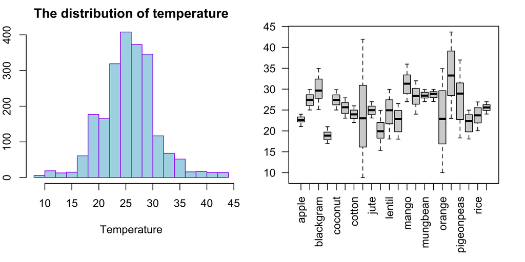

## Your turn

The same:

- Copy the code and revise the arguments (variables, colors, etc) to your own choices.
- Share your figure in Google chat.

## `ggplot2`

Details in [`ggplot2` package document](https://ggplot2.tidyverse.org/reference/index.html).

- Basic syntax

```r
my_plot <- ggplot(dt, aes(x = ., y = ., fill = ., color = ., ...)) + # Data
  geom_point(aes(...)) + # geom
  ... +
  facet_wrap() + # organize sub-plots
  # scale
  scale_fill_manual(values=c("red", "blue", ...)) + # customize fill color
  scale_color_manual(values=c("red", "green", ...)) + # customize color
  labs(x = 'x axis', y = 'y axis', title = 'main title') + # titles
  coord_polar() + # sometimes you might want to change the coordinate system
  theme_bw()  + # ggplot2 theme
  theme() # Customize other settings
```

An aesthetic is a visual property of the objects in your plot. It includes things like the size, the shape, or the color of your points. So if you want `ggplot2` to take your settings of these things, you have to put them into aesthetic.

## Some geom functions in `ggplot2`

- `geom_point()`: scatter plot
- `geom_line()`: line plot
- `geom_histogram()`: histogram
- `geom_bar()`: bar plot with base on the x-axis
- `geom_boxplot()`: standard box plot with boxes and whiskers
- `geom_smooth()`: smooth curve

## `ggplot2` vs. base R

Let’s reconstruct all example figures with `ggplot2`.

## Same scatterplot with `ggplot2`

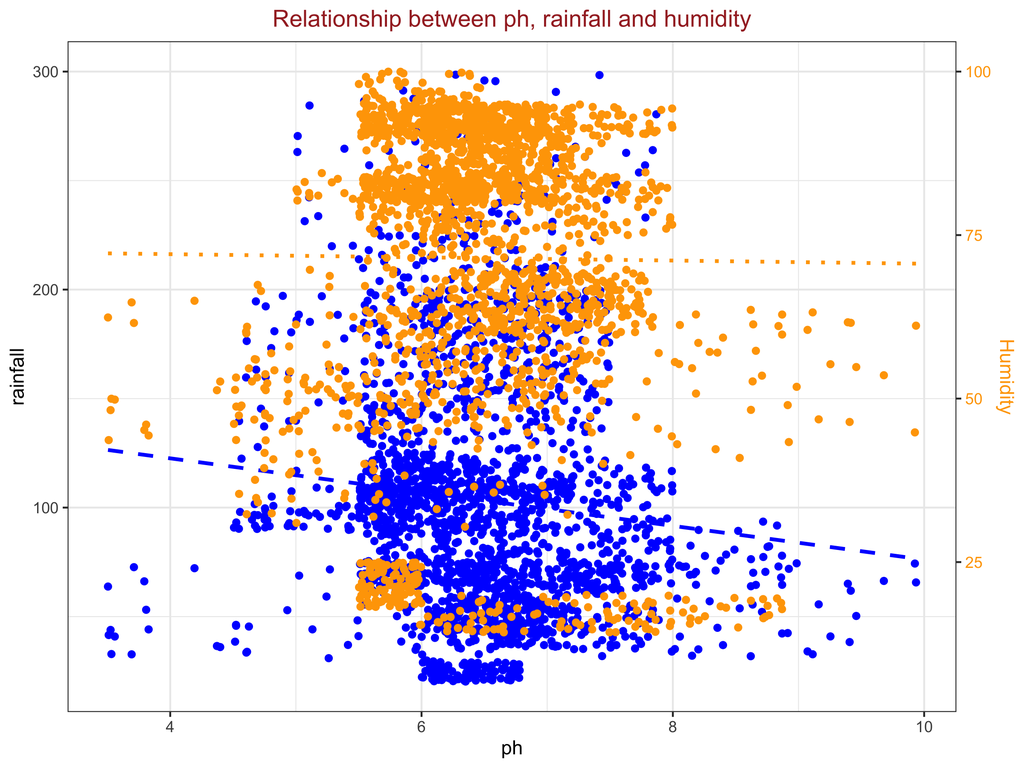

## Same scatterplot with `ggplot2`

```r
ggplot(crops) + # data
    # add scatter points for rainfall
    geom_point(aes(x = ph, y = rainfall),
               color = 'blue') +
    # add the fitted line for rainfall
    geom_smooth(aes(x = ph, y = rainfall),
                method = "lm", se = FALSE,
                color = 'blue', linetype = 2) +
    # add scatter points for humidity
    geom_point(aes(x = ph, y = humidity * 3),
               color = 'orange') +
    # add fitted line for humidity
    geom_smooth(aes(x = ph, y = humidity * 3),
                method = "lm", se = FALSE,
                color = 'orange', linetype = 3) +
    # Add a second axis and specify its features
    scale_y_continuous(
        # make sure the ranges match
        sec.axis = sec_axis(~.*(1 / 3), name = "Humidity")) +
    # Set titles
    labs(x = "ph",
         title = 'Relationship between ph, rainfall and humidity') +
    # Set theme
    theme_bw() +
    theme(axis.text.y.right = element_text(color = "orange"),
          axis.title.y.right = element_text(color = "orange"),
          plot.title = element_text(color = "brown", hjust = 0.5))
```

## Same histogram with boxplot

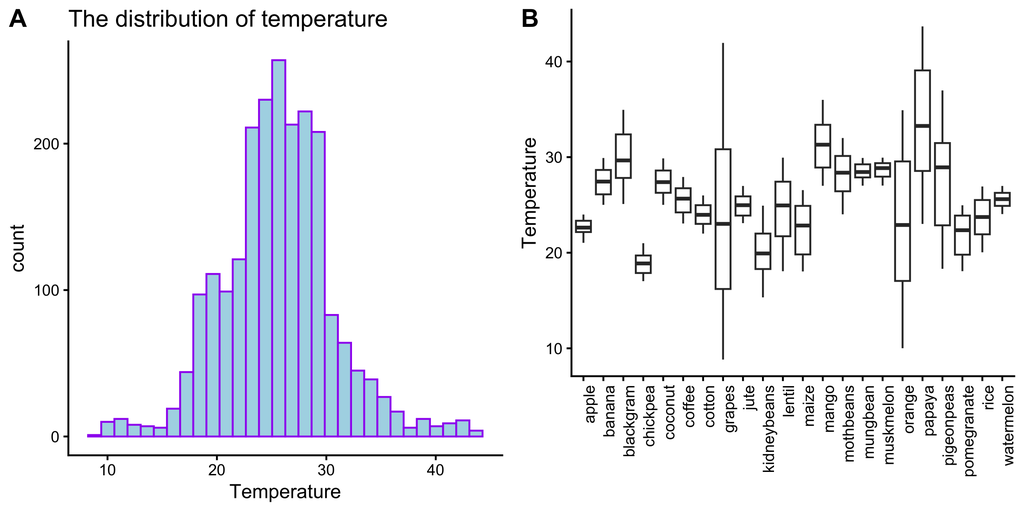

## Same histogram with boxplot

```r
# Plot the histogram
p1 <- ggplot(crops) + # set data
    # add histogram
    geom_histogram(aes(x = temperature),
                   fill = 'lightblue', color = 'purple') +
    # set titles
    labs(x = 'Temperature', title = 'The distribution of temperature') +
    # Set theme
    theme_classic()

# plot the boxplot
p2 <- ggplot(crops) +
    geom_boxplot(aes(x = label, y = temperature)) +
    labs(y = 'Temperature', x = '') +
    theme_classic() +
    theme(axis.text.x = element_text(angle = 90, hjust = 1))

# Put together, need package cowplot
cowplot::plot_grid(p1, p2, labels = "AUTO")
```

## Groups in `ggplot2`

- Set color or shape in `aes`.

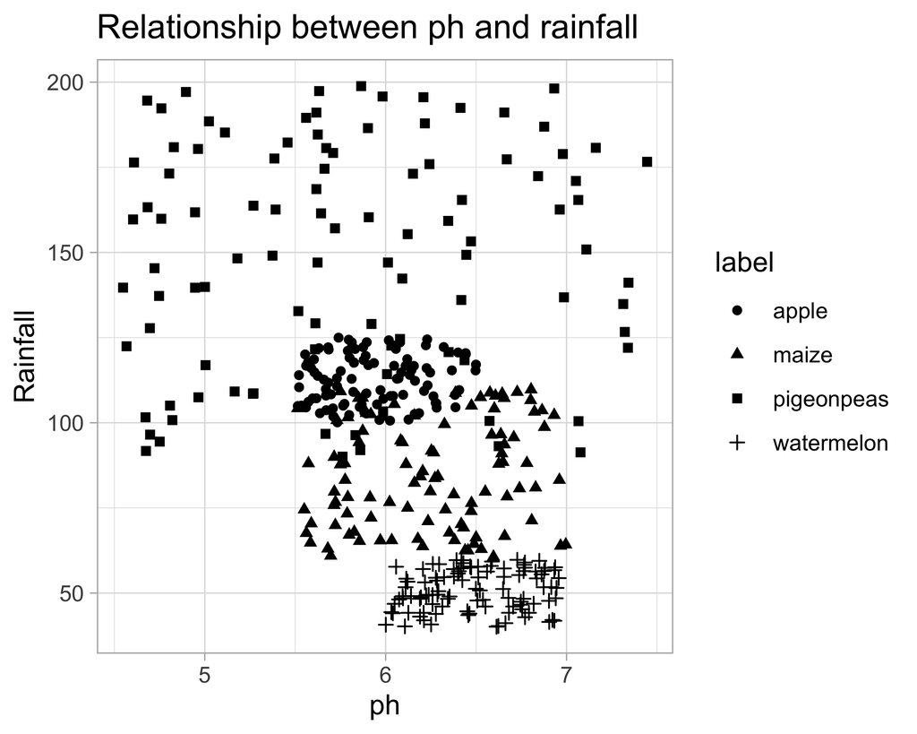

```r
# Subset the dataset
set.seed(12)
crops_sub <- crops %>%
  filter(label %in% sample(unique(crops$label), 4))

## Use different shape for groups
ggplot(crops_sub) +
  geom_point(aes(x = ph, y = rainfall,
                 shape = label)) +
  labs(x = 'ph',
       y = 'Rainfall',
       title = 'Relationship between ph and rainfall') +
  theme_light()
```

## Your turn

- Adjust the code to use different colors for groups.

## Facets in `ggplot2`

- Use different panels

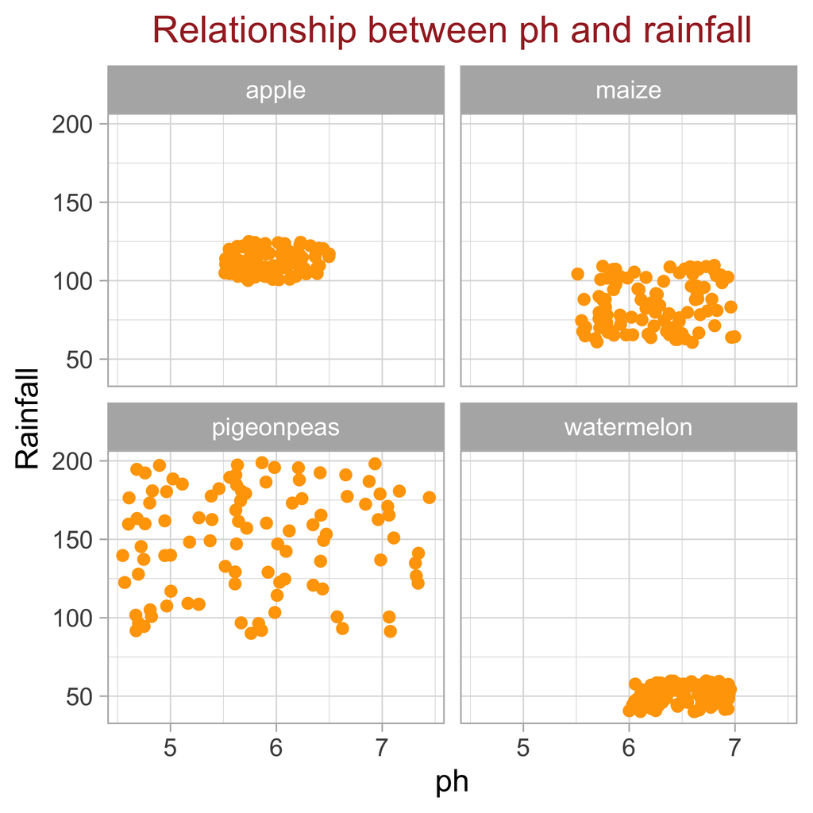

```r
ggplot(crops_sub) +
  geom_point(aes(x = ph, y = rainfall), color = 'orange') +
  facet_wrap(~ label) + # Split which into different panels
  labs(x = 'ph',
       y = 'Rainfall',
       title = 'Relationship between ph and rainfall') +
  theme_light() +
  theme(plot.title = element_text(color = "brown", hjust = 0.5))
```

## Homework

- Assignment 3 due this Friday.
- **Important:** finish [Weekly homework](https://lei-song.shinyapps.io/SDA320-homework/#section-spotted-hyenas-distribution) (Spotted Hyenas Distribution).